# 6 Visualización de datos

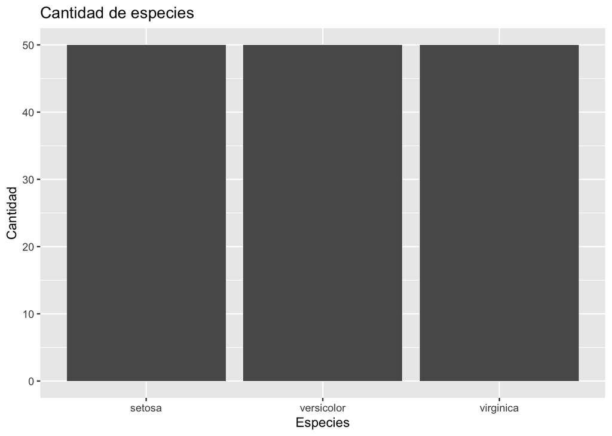

```r
iris %>%
  ggplot(aes(x = Species)) +
  geom_bar() +
  labs(
    title = "Cantidad de especies",
    x = "Especies",
    y = "Cantidad"
  )
```

También pueden agregarse otros elementos estéticos al gráfico, como las etiquetas de datos y los colores de las gráficas. Con respecto a las etiquetas, con la función *geom_text* suele bastar con agregar *label = variable_en_eje_y* pero como en éste caso no hay, es un poco más complejo. El parámetro *just* varía según si es vertical u horizontal, y refiere a la ubicación. Si cambiamos el valor, cambia donde queda la etiqueta.

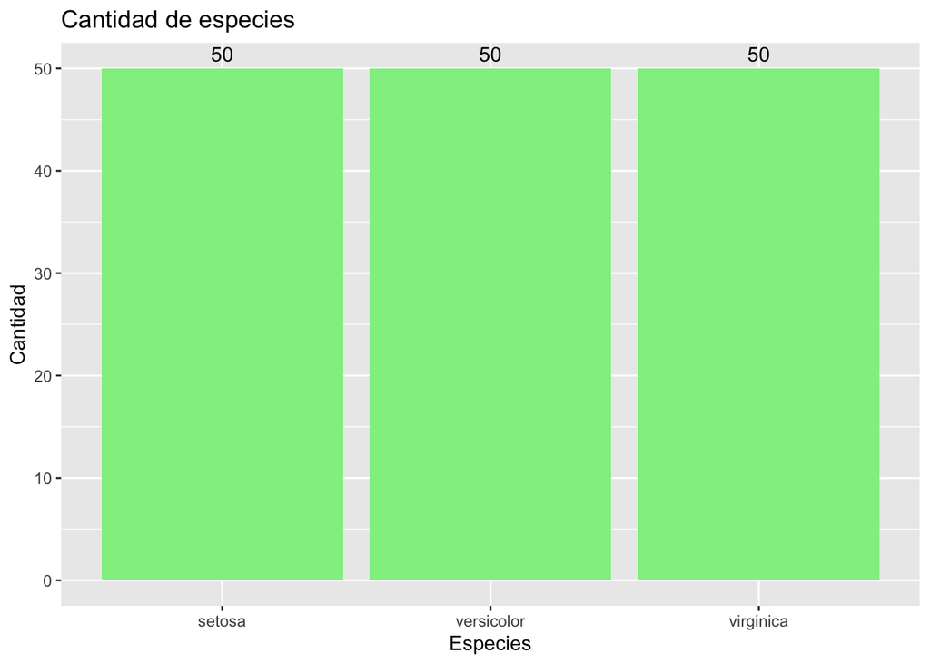

```r
iris %>%
  ggplot(aes(x = Species)) +
  geom_bar(fill = 'lightgreen') +
  labs(
    title = "Cantidad de especies",
    x = "Especies",
    y = "Cantidad"
  ) +
  geom_text(aes(label = ..count..), stat = "count", vjust = -0.5)
```

Finalmente, pueden seleccionarse temas dentro de ggplot que permiten una mejora visual de todos los elementos del gráfico. Hay muchos para elegir y pueden aportar mucho en términos de visualización.

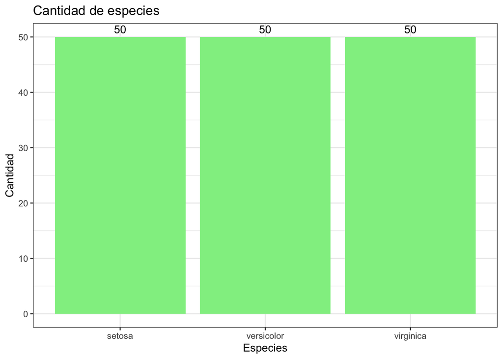

```r
iris %>%
  ggplot(aes(x = Species)) +
  geom_bar(fill = 'lightgreen') +
  labs(
    title = "Cantidad de especies",
    x = "Especies",
    y = "Cantidad"
  ) +
  geom_text(aes(label = ..count..), stat = "count", vjust = -0.5) +
  theme_bw()
```

## 6.2 Tipos de gráfico

### De barras horizontales

Ya vimos cómo generar un gráfico de barras clásico, pero a veces resulta conveniente tenerlas de forma horizontal. Para esto, se puede usar la función *coord_flip.*

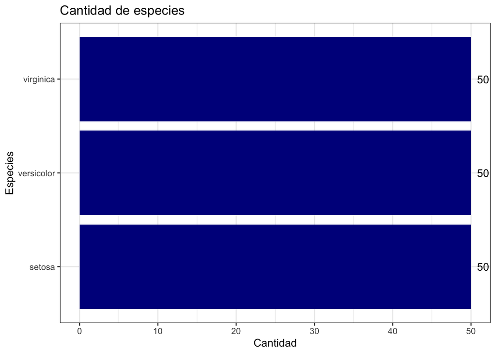

```r
iris %>%
  ggplot(aes(x = Species)) +
  geom_bar(fill = 'darkblue') +
  labs(
    title = "Cantidad de especies",
    x = "Especies",
    y = "Cantidad"
  ) +
  geom_text(aes(label = ..count..), stat = "count", hjust = -0.5) +
  coord_flip() +
  theme_bw()
```

Cuando queremos graficar ciertos datos, conviene previamente armar una tabla que permita simplemente representar los resultados. Si bien ggplot puede elaborarse a partir de cálculos con el dataset entero, conviene dejarle los números dados.

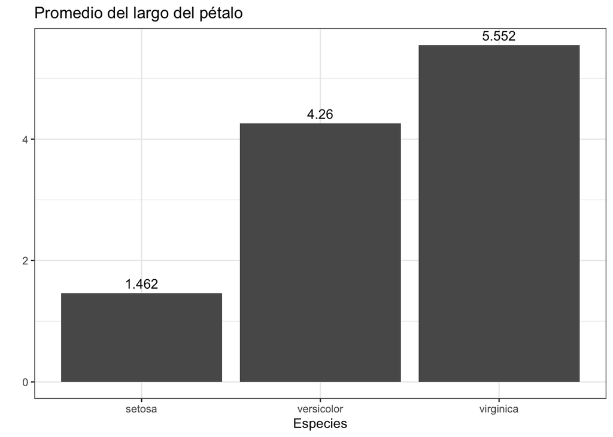

```r
iris %>%
  group_by(Species) %>%
  summarise(promedio_largo_hojas = mean(Petal.Length)) %>%
  ggplot(aes(x = Species, y = promedio_largo_hojas)) +
  geom_bar(stat = 'identity') +
    labs(
    title = "Promedio del largo del pétalo",
    x = "Especies",
    y = ""
  ) +
  geom_text(aes(label = promedio_largo_hojas), vjust = -0.5) +
  theme_bw()
```

### Barras acumuladas

Las barras acumuladas implican tener que pasarle una variable a *ggplot* para que acumule. Si realizamos un *summarise,* éste naturalmente nos devolvera una columna por cada cálculo. Tenemos que adaptarlo a las necesidades de *ggplot* mediante la función [*gather*](https://www.rdocumentation.org/packages/tidyr/versions/0.5.1/topics/gather)*,* que sirve para hacer un **despivotamiento de columnas**.

Un despivotamiento de columnas es básicamente pasar una serie de columnas a tan solo dos: una que sea el concepto y otra el valor, y duplicar filas para no perder información.

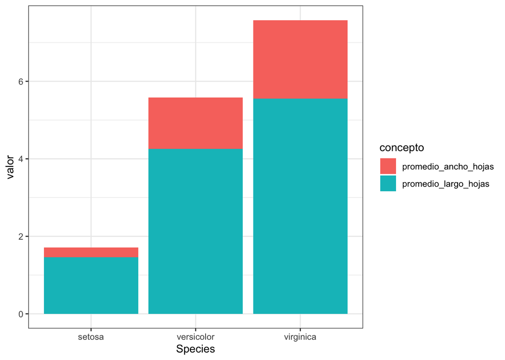

```r
iris %>%
  group_by(Species) %>%
  summarise(
    promedio_largo_hojas = mean(Petal.Length),
    promedio_ancho_hojas = mean(Petal.Width)
  ) %>%
  gather("concepto", "valor", 2:3) %>%
  ggplot(aes(x= Species, y = valor, fill = concepto)) +
  geom_bar(stat = 'identity') +
  theme_bw()
```

Este método se debe usar tanto para acumulación de barras como al usarlas en posición *dodge.*

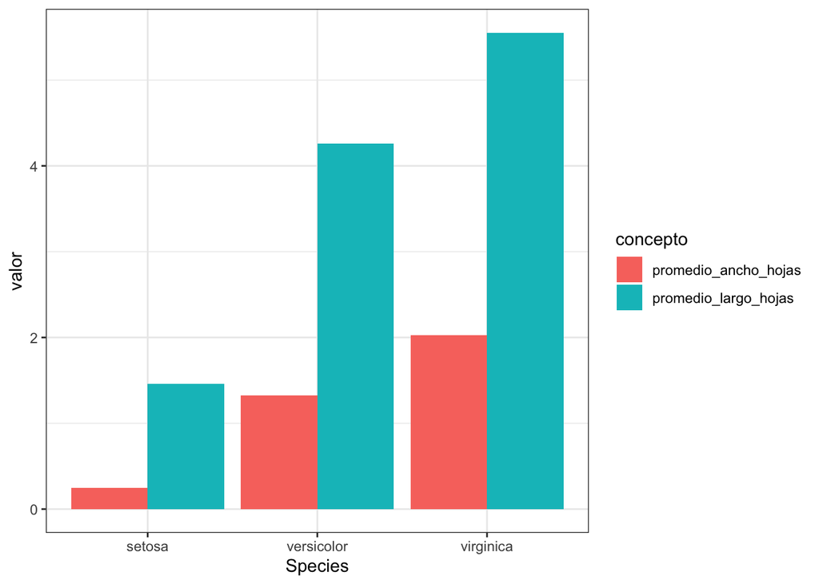

```r
iris %>%
  group_by(Species) %>%
  summarise(
    promedio_largo_hojas = mean(Petal.Length),
    promedio_ancho_hojas = mean(Petal.Width)
  ) %>%
  gather("concepto", "valor", 2:3) %>%
  ggplot(aes(x= Species, y = valor, fill = concepto)) +
  geom_bar(stat = 'identity',position = position_dodge()) +
  theme_bw()
```

### Gráficos de dispersión

Los gráficos de dispersión son básicos en cualquier análisis cuantitativo. Se pueden generar fácilmente con *ggplot* y además agregar variables categóricas para segmentar. Finalmente la función que se utiliza es *geom_point().*

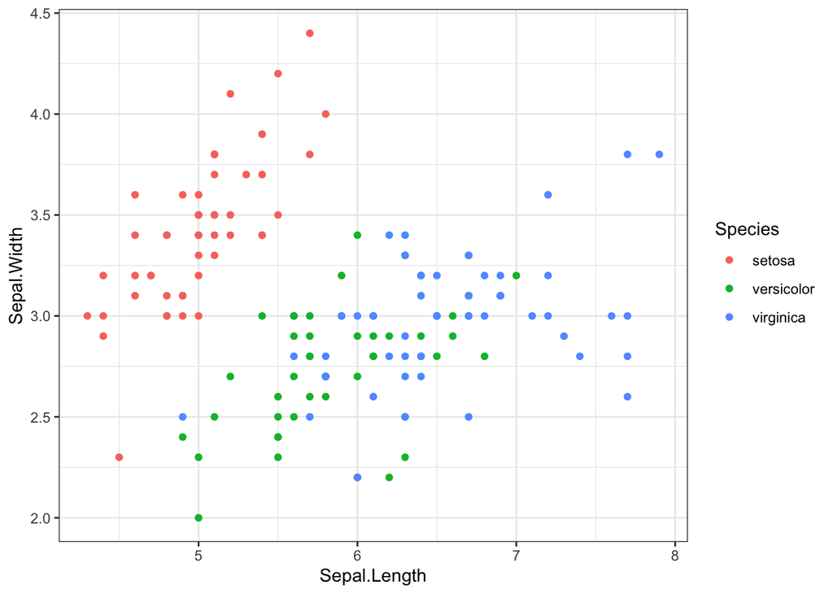

```r
iris %>%
  ggplot(aes(x = Sepal.Length, y = Sepal.Width, color = Species)) +
  geom_point() +
  theme_bw()
```

### Histogramas

Para realizar tanto histogramas como boxplot, es camino es bastante directo.

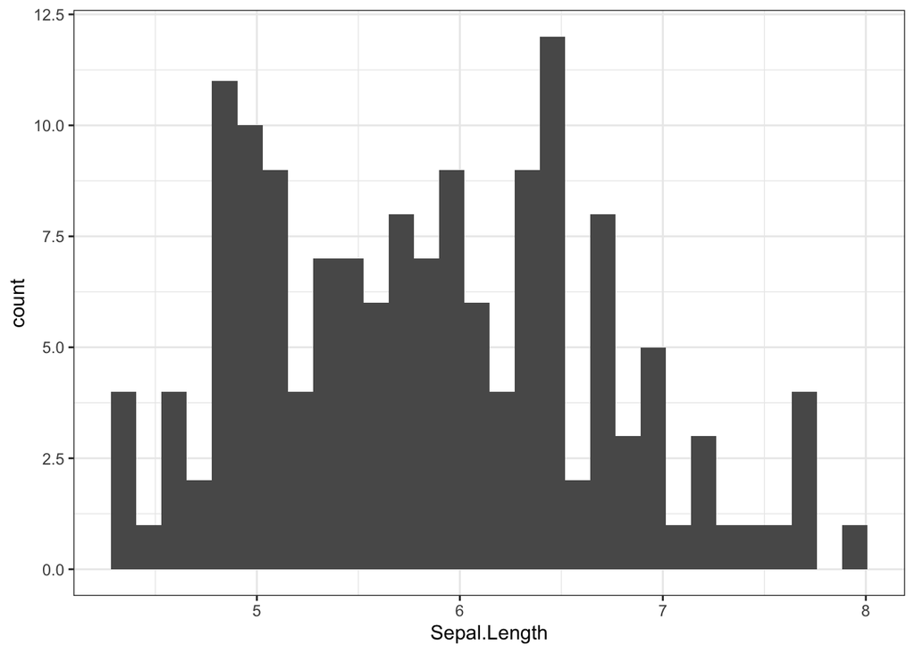

```r
iris %>%
  ggplot(aes(x = Sepal.Length)) +
  geom_histogram() +
  theme_bw()
```

### Boxplot

Si bien la estructura de ggplot es sencilla, es muy personalizable de acuerdo a lo que necesite el analista.

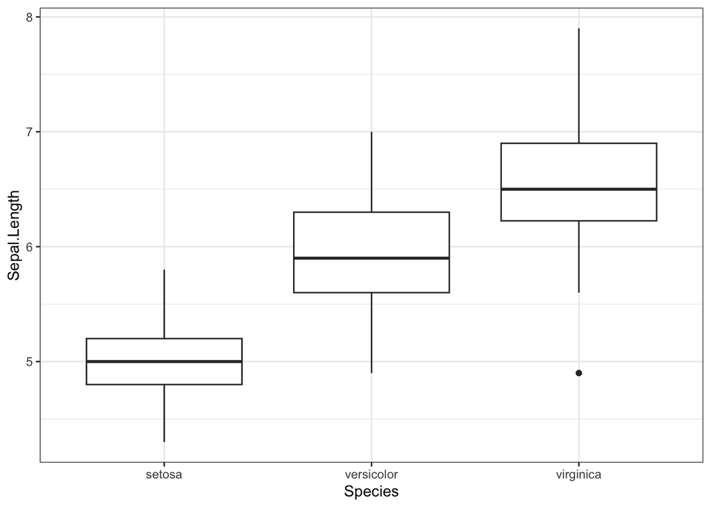

```r
iris %>%
  ggplot(aes(x = Species, y = Sepal.Length)) +
  geom_boxplot() +
  theme_bw()
```

Si quieren conocer a fondo las cuestiones de visualización y ver más tipos de gráficos, recomiendo [este libro](https://r-graphics.org/index.html).

## 6.3 Desafío

Obtenga el dataset “datos_ventas” y realice las siguientes operaciones:

1. Genere una gráfica de barras verticales que muestre la cantidad de ventas (filas) que hubo por color de producto.
2. Genere un gráfico de barras horizontales que muestre el total de ingreso por departamento.
3. Investigue cómo generar un gráfico de lineas que le permita hacer una evolución de las ganancias.
- Cuidado con los NAs
- Cada gráfico debe tener una temática junto con sus nombres de ejes y etiquetas.

**Posible solución**

```r
library(openxlsx)
ventas <- read.xlsx("../data/Chapter_6/data_c_1.xlsx", detectDates = TRUE)

# Primer ejercicio

ventas %>%
  group_by(Color) %>%
  summarise(ventas = n()) %>%
  ggplot(aes(x = Color, y = ventas)) +
  geom_col() +
  labs(
    title = "Cantidad de ventas por color",
    x = "",
    y = ""
  ) +
  geom_text(aes(label = ventas), vjust = -0.5) +
  theme_bw()

# Segundo ejercicio

ventas %>%
  mutate(ingreso = Cantidad * Monto) %>%
  group_by(Departamento) %>%
  summarise(ingreso = sum(ingreso, na.rm = TRUE)) %>%
  ggplot(aes(x = Departamento, y = ingreso)) +
  geom_bar(stat = 'identity') +
  labs(
    title = "Ingreso total por departamento",
    x = "",
    y = ""
  ) +
  coord_flip() +
  geom_text(aes(label = ingreso), hjust = 1.1, color = 'white') +
  theme_bw()

# Tercer ejercicio

ventas %>%
  mutate(ingreso = Cantidad * Monto) %>%
  group_by(Fecha) %>%
  summarise(ingreso = sum(ingreso, na.rm = TRUE)) %>%
  ggplot(aes(x = Fecha, y = ingreso)) +
  geom_line() +
  labs(
    title = "Evolución de la ganancia",
    x = "",
    y = ""
  ) +
  theme_bw()
```